# Cyber_Presentation

Wei Ting

5/2/2020

# Research Questions

## What is the most common types of cyber operation ? Trend by years?

## Countries are more likely to be Sponsors (top 10?)?

## Frequency of cyberattacks conducted by top five countries?

## Do super power (US, China and Russia) more likely to sponsor cyber incidents, compared to middle power?

## How do victims respond to the attacks?

# 1. Collecting Data

### I collect data from the Cyber Operations Tracker (Council of Foreign Relations)

https://www.cfr.org/interactive/cyber-operations

## General setting

```r
# remove all objects
rm(list=ls())

# Unload all packages
library(pacman)
pacman::p_unload(all)
```

```
## The following packages have been unloaded:
## pacman
```

```r
library(tidyverse)
library(stringr)

# Add packages
pacman::p_load(
  tidyverse, #dplyr, readr, etc.
  data.table, #fread()
  foreign, #load data types including stata .dta files
  magrittr, #%<>% operator
  skimr #for summerising
)
```

```r
# Change default plot dimensions
knitr::opts_chunk$set(fig.width=12, fig.height=8)

# Load themes
theme_ed_bigtxt <- theme(
  text = element_text(size=16),
  plot.caption = element_text(colour="black",size=10),
  axis.text.y = element_text(colour="black",size=16),
  axis.text.x = element_text(colour="black",size=16),
  legend.text = element_text(colour="black",size=16),
  legend.position = "bottom",
  panel.background = element_rect(fill = NA),
  panel.border = element_rect(fill = NA, color = "grey75"),
  axis.ticks = element_line(color = "grey85"),
  panel.grid.major = element_line(color = "grey95", size = 0.2),
  panel.grid.minor = element_line(color = "grey95", size = 0.2),
  legend.key = element_blank())

theme_ed <- theme(
  legend.position = "bottom",
  panel.background = element_rect(fill = NA),
  panel.border = element_rect(fill = NA, color = "grey75"),
  axis.ticks = element_line(color = "grey85"),
  panel.grid.major = element_line(color = "grey95", size = 0.2),
  panel.grid.minor = element_line(color = "grey95", size = 0.2),
  legend.key = element_blank())
```

```r
#Import data
cyber <- read.csv("/Users/weitin/OneDrive/cyberdata.csv",
                  header = TRUE,
                  #stringsAsFactors = T,
                  na.strings = c("", " ", "999", "?", "NONE", "none"))

glimpse(cyber)
```

```
## Observations: 389
## Variables: 12
## $ Title        <fct> "Targeting of secure messaging app used by Hong Kong pro…
## $ Date         <fct> 2019-06-13, 2019-11-25, 2019-03-12, 2019-09-26, 2019-10-…
## $ Affiliations <fct> "Hong Kong police", "Gamaredon", "Believed to be the wor…
## $ Description  <fct> "Hong Kong authorities used a network of Chinese compute…
## $ Response     <fct> NA, NA, NA, NA, NA, NA, NA, NA, NA, NA, NA, NA, NA, NA, …
## $ Victims      <fct> "Hong Kong", "Ukrainian government entities", "Indonesia…
## $ Sponsor      <fct> "Hong Kong", "Russian Federation", "China, Russian Feder…
## $ Type         <fct> Espionage, Espionage, Espionage, Espionage, Espionage, E…
## $ Category     <fct> Civil society, Government, Government, Private sector, C…
## $ Sources_1    <fct> https://www.bloomberg.com/news/articles/2019-08-31/hong-…
## $ Sources_2    <fct> https://www.nytimes.com/2019/06/13/world/asia/hong-kong-…
## $ Sources_3    <fct> NA, NA, NA, NA, NA, NA, NA, NA, NA, NA, NA, NA, NA, NA, …
```

```r
#select interested data
cyber_2 <-select(cyber,Title,Date, Affiliations,Description,Response,Victims,Sponsor, Type, Category)
```

```r
cyber_2 %>% skimr::skim()
```

Data summary

| Name | Piped data |
| --- | --- |
| Number of rows | 389 |
| Number of columns | 9 |
| _______________________ |  |
| Column type frequency: |  |
| factor | 9 |
| ________________________ |  |
| Group variables | None |

**Variable type: factor**

| skim_variable | n_missing | complete_rate | ordered | n_unique | top_counts |
| --- | --- | --- | --- | --- | --- |
| Title | 0 | 1.00 | FALSE | 386 | Tar: 4, 201: 1, A c: 1, adm: 1 |
| Date | 6 | 0.98 | FALSE | 334 | 201: 6, 201: 4, 201: 3, 201: 3 |
| Affiliations | 124 | 0.68 | FALSE | 215 | Bel: 15, Bel: 7, Bel: 5, Bel: 4 |
| Description | 0 | 1.00 | FALSE | 386 | Gam: 4, A C: 1, A C: 1, A c: 1 |
| Response | 321 | 0.17 | FALSE | 62 | Cri: 2, Cri: 2, Cri: 2, Cri: 2 |
| Victims | 23 | 0.94 | FALSE | 307 | Uni: 21, Sou: 7, Ukr: 7, Ger: 6 |
| Sponsor | 41 | 0.89 | FALSE | 33 | Chi: 138, Rus: 88, Ira: 40, Kor: 31 |
| Type | 20 | 0.95 | FALSE | 6 | Esp: 311, Sab: 19, Den: 18, Dat: 12 |
| Category | 11 | 0.97 | FALSE | 4 | Gov: 167, Pri: 122, Civ: 54, Mil: 35 |

```r
glimpse(cyber_2)
```

```
## Observations: 389
## Variables: 9
## $ Title        <fct> "Targeting of secure messaging app used by Hong Kong pro…
## $ Date         <fct> 2019-06-13, 2019-11-25, 2019-03-12, 2019-09-26, 2019-10-…
## $ Affiliations <fct> "Hong Kong police", "Gamaredon", "Believed to be the wor…
## $ Description  <fct> "Hong Kong authorities used a network of Chinese compute…
## $ Response     <fct> NA, NA, NA, NA, NA, NA, NA, NA, NA, NA, NA, NA, NA, NA, …
## $ Victims      <fct> "Hong Kong", "Ukrainian government entities", "Indonesia…
## $ Sponsor      <fct> "Hong Kong", "Russian Federation", "China, Russian Feder…
## $ Type         <fct> Espionage, Espionage, Espionage, Espionage, Espionage, E…
## $ Category     <fct> Civil society, Government, Government, Private sector, C…
```

# 2. Constructing the Analysis Dataset: What was involved in cleaning / pre-processing / subsetting / merging the data?

## Preprocessing

### try to seperate response and link

```r
v0<-strsplit(as.character(cyber_2$Response)," ")


check0<-lengths(v0,use.names = F)
check0 # there mignt be one, four, or five spaces.
```

```
##   [1] 1 1 1 1 1 1 1 1 1 1 1 1 1 1 1 1 1 1 1 1 1 1 4 1 1 1 1 1 1 1 1 1 1 1 1 1 1
##  [38] 1 1 1 1 1 1 1 1 4 1 1 1 1 1 1 1 4 1 1 1 1 1 1 4 1 1 1 1 1 1 1 1 1 1 1 1 1
##  [75] 1 1 1 1 5 1 1 1 4 1 1 4 1 1 1 1 5 1 1 1 1 5 1 1 1 1 1 1 1 1 1 1 4 1 4 1 1
## [112] 1 1 1 1 1 1 1 1 1 1 5 1 1 1 1 4 1 1 4 1 1 4 1 1 1 5 1 1 1 1 1 1 1 1 1 5 1
## [149] 1 1 1 1 1 1 1 1 5 1 1 1 1 1 1 1 4 1 4 1 1 4 1 1 4 1 1 4 1 4 1 1 4 1 1 1 1
## [186] 1 4 1 1 1 1 1 1 4 1 1 1 1 1 1 1 1 4 1 1 1 1 4 1 5 4 1 1 4 1 1 1 4 4 1 1 1
## [223] 1 1 1 1 1 1 1 1 1 5 1 1 1 1 1 4 1 1 1 1 1 5 1 1 1 1 1 1 1 4 1 1 1 1 4 1 1
## [260] 4 1 4 4 1 1 1 4 4 1 1 1 1 1 1 1 4 1 1 4 1 4 1 1 1 1 1 1 1 1 1 1 1 4 1 4 5
## [297] 1 5 1 4 1 1 1 1 1 1 1 4 1 1 1 5 4 1 1 1 1 1 1 1 1 1 1 4 1 1 1 1 1 1 1 1 5
## [334] 5 1 1 1 1 1 1 1 4 1 4 1 1 4 1 1 1 4 1 1 4 1 4 1 1 1 1 4 1 1 1 1 1 1 1 4 4
## [371] 4 1 1 1 1 1 1 1 1 1 1 1 1 1 1 1 1 1 1
```

```r
length(which(check0!=1)) # check: there are 68 which are four or five spaces.
```

```
## [1] 68
```

```r
d0 <- data.table(target = cyber_2$Response) # take out the targeted column "sponsor"

# Delimiter may be multipal space.
d0[, c("1", "2","3","4","5") := tstrsplit(target, " ")] # Break them into five columns.
d1 <- sapply(d0, as.character) # Return a list with same length
d1[is.na(d1)] <- " " # now resplace all missing value as one space
 d1<-as.data.frame(d1)

 #d1 <- data.table(d1)

d2 <- d1 %>%
  unite(col =Response_type , '1', '2', sep = " ")  %>% # gathering words
  unite(col =link , '4', '5', sep = " ") # gathering link
#d2 # now there's only one space delimiter
Sponsor_cleaned<-d2[,c("Response_type","link" )]
```

###update data

```r
cyber_2_1<-cbind(cyber_2,Sponsor_cleaned)
```

### Grip incident which have responses

```r
new_var_ind1<-grep("Confirmation",cyber_2$Response)
new_var_ind2<-grep("Denouncement",cyber_2$Response)
new_var_ind3<-grep("Criminal charges",cyber_2$Response)
new_var_ind4<-grep("Sanctions",cyber_2$Response)
new_var_ind5<-grep("Denial",cyber_2$Response)
new_var_ind6<-grep(" ",cyber_2$Response)

keytopic_id<-c(new_var_ind1,new_var_ind2,new_var_ind3,new_var_ind4,new_var_ind5,new_var_ind6)

# New dataframe that contains incidents which are responded
cyber_3<-cyber_2_1[keytopic_id,]
head(cyber_3)
```

```
##                                                                     Title
## 23                                   Compromise of British infrastructure
## 54                                                   Compromise of Yandex
## 61                                      Attacks on private U.S. companies
## 109                     Compromise of U.S. electric utility control rooms
## 46                                     Attack on Iranian computer systems
## 83  Targeting of the Organization for the Prohibition of Chemical Weapons
##           Date
## 23  2019-04-02
## 54  2019-06-27
## 61  2019-06-22
## 109 2018-07-23
## 46  2019-06-22
## 83  2018-10-04
##                                                                                         Affiliations
```

[output cut: 48 more lines]

### identify state victims

```r
table(cyber_2_1$Category)
```

```
##
##  Civil society     Government       Military Private sector
##             54            167             35            122
```

```r
# Add a column "state_victim"
 cyber_2_1  %<>%
   mutate(state_victim = ifelse(Category %like% 'Government|Civil society|Military',T, F))
```

```r
 table(cyber_2_1$Sponsor)
```

```
##
##                                                         China
##                                                           138
##                                     China, Russian Federation
##                                                             2
##                                                         Egypt
##                                                             1
##                                                      Ethiopia
##                                                             1
##                                                        France
##                                                             1
##                                                     Hong Kong
##                                                             1
##                                                         India
##                                                             1
##                                                     Indonesia
##                                                             1
##                                    Iran (Islamic Republic of)
##                                                            40
##                                                        Israel
##                                                             4
##                                         Israel, United States
##                                                             1
##                                                    Kazakhstan
##                                                             1
##                       Korea (Democratic People's Republic of)
##                                                            31
##                                           Korea (Republic of)
##                                                             1
##                                                       Lebanon
##                                                             1
##                                                        Mexico
##                                                             2
##                                                       Morocco
##                                                             1
##                                                   Netherlands
##                                                             1
##                                                      Pakistan
##                                                             2
##                                                        Panama
```

[output cut: 12 more lines]

```
##                                                             4
##                                                United Kingdom
##                                                             1
##                                 United Kingdom, United States
##                                                             1
##                                                 United States
##                                                             9
## United States, Australia, Canada, New Zealand, United Kingdom
##                                                             1
##                                         United States, Israel
##                                                             2
##                                                    Uzbekistan
##                                                             1
##                                                       Vietnam
##                                                             3
```

```r
 # Create three types
 cyber_2_1 %<>%
   mutate(state_cat = ifelse(Sponsor %like%  'China|United States|Russian Federation', "Super Power","Middle Power"))

 #  update missing data as NA, or it would be coded as "Middle Power"
 cyber_2_1$state_cat[is.na(cyber_2_1$Sponsor)]<-"NA"

 # Check
 cyber_2_1[is.na(cyber_2_1$Sponsor),c("Sponsor","state_cat")]
```

```
##     Sponsor state_cat
## 8      <NA>        NA
## 42     <NA>        NA
## 49     <NA>        NA
## 50     <NA>        NA
## 58     <NA>        NA
## 65     <NA>        NA
## 72     <NA>        NA
## 73     <NA>        NA
## 84     <NA>        NA
## 85     <NA>        NA
## 92     <NA>        NA
## 95     <NA>        NA
## 103    <NA>        NA
## 105    <NA>        NA
```

[output cut: 27 more lines]

### Date

```r
cyber_2_1 %<>%
   # Convert date variable to date type
   mutate(date_orig = Date,
          Date = lubridate::ymd(date_orig)) %>%
   # Add year variable
   mutate(Year = year(Date))
head(cyber_2_1)
```

```
##                                                                                        Title
## 1                             Targeting of secure messaging app used by Hong Kong protesters
## 2                                                 Targeting of Ukrainian government entities
## 3                                                                  2019 Indonesian elections
## 4                                                             Compromise of Airbus suppliers
## 5                                                           Targeting of Egyptian dissidents
## 6 Targeting of the Australian Parliament, including the Liberal, National, and Labor Parties
##         Date
## 1 2019-06-13
## 2 2019-11-25
## 3 2019-03-12
## 4 2019-09-26
## 5 2019-10-03
## 6 2019-08-15
##                                                                            Affiliations
```

[output cut: 41 more lines]

# 3. Analysis: What kinds of analyses did you perform? (My Research Questions )

## What is the most common types of cyber operation ? Trend by years?

## Countries are more likely to be Sponsors (top 10?)?

## Frequency of cyberattacks conducted by top five countries?

## Do super power (US, China and Russia) more likely to sponsor cyber incidents, compared to middle power?

## How do victims respond to the attacks?

# 4. Results / Visualization: What results did you find? How did you visualize these results?

### Summarize data

```r
 # summarize attacks category
 suma_attackcat = cyber_2_1 %>%
   filter(!is.na(Category))%>%
   filter(!is.na(Year))%>%
   group_by(Category, Year) %>%
   summarise(sum=n())
 print(suma_attackcat)
```

```
## # A tibble: 47 x 3
## # Groups:   Category [4]
##    Category       Year   sum
##    <fct>         <int> <int>
##  1 Civil society  2008     2
##  2 Civil society  2010     1
##  3 Civil society  2012     1
##  4 Civil society  2015     1
##  5 Civil society  2016     8
##  6 Civil society  2017     9
##  7 Civil society  2018    16
##  8 Civil society  2019    15
##  9 Government     2006     1
## 10 Government     2007     4
## # … with 37 more rows
```

```r
 # summarize sponsor states
 suma_sponstates = cyber_2_1 %>%
   filter(!is.na(Sponsor)) %>%
   filter(!is.na(Year))%>%
   group_by(Sponsor, Year) %>%
   summarise(sum_sponstates = n())
 print(suma_sponstates)
```

```
## # A tibble: 84 x 3
## # Groups:   Sponsor [33]
##    Sponsor  Year sum_sponstates
##    <fct>   <int>          <int>
##  1 China    2005              1
##  2 China    2006              3
##  3 China    2007              7
##  4 China    2008              5
##  5 China    2009              3
##  6 China    2010              6
##  7 China    2011              9
##  8 China    2012              5
##  9 China    2013             11
## 10 China    2014             17
## # … with 74 more rows
```

```r
 # summarize victims
 suma_victims = cyber_2_1 %>%
   filter(!is.na(Victims)) %>%
   group_by(Victims, Year, state_victim) %>%
   summarize(sum_victims = n())
 print(suma_victims)
```

```
## # A tibble: 337 x 4
## # Groups:   Victims, Year [332]
##    Victims                                         Year state_victim sum_victims
##    <fct>                                          <int> <lgl>              <int>
##  1 A U.S. presidential campaign, government offi…  2019 TRUE                   1
##  2 Aerospace companies based in Arizona, Massach…  2018 FALSE                  1
##  3 Airbus                                          2019 FALSE                  1
##  4 Algeria, Afghanistan, Belgium, Brazil, Fiji, …  2014 TRUE                   1
##  5 AMC Theatres                                    2018 FALSE                  1
##  6 Amnesty International Hong Kong                 2019 TRUE                   1
##  7 An unnamed U.S. presidential campaign           2019 TRUE                   1
##  8 Anthem                                          2015 FALSE                  1
##  9 Apple iCloud in China                           2014 FALSE                  1
## 10 Argentina, Brazil, Peru, Ecuador, Brunei, Mal…  2017 TRUE                   1
## # … with 327 more rows
```

```r
  # Summarize statepower
 suma_statepower = cyber_2_1 %>%
   filter(!is.na(state_cat)) %>%
   group_by(state_cat,Year) %>%
   summarise(sum = n())

 print(suma_statepower)
```

```
## # A tibble: 37 x 3
## # Groups:   state_cat [3]
##    state_cat     Year   sum
##    <chr>        <int> <int>
##  1 Middle Power  2007     1
##  2 Middle Power  2009     1
##  3 Middle Power  2010     2
##  4 Middle Power  2011     3
##  5 Middle Power  2012     5
##  6 Middle Power  2013     4
##  7 Middle Power  2014     8
##  8 Middle Power  2015     9
##  9 Middle Power  2016     9
## 10 Middle Power  2017    15
## # … with 27 more rows
```

```r
 # reshape statepower
 head(suma_statepower)
```

```
## # A tibble: 6 x 3
## # Groups:   state_cat [1]
##   state_cat     Year   sum
##   <chr>        <int> <int>
## 1 Middle Power  2007     1
## 2 Middle Power  2009     1
## 3 Middle Power  2010     2
## 4 Middle Power  2011     3
## 5 Middle Power  2012     5
## 6 Middle Power  2013     4
```

```r
suma_statepower_reshape <- spread(suma_statepower,Year,sum)
head(suma_statepower_reshape)
```

```
## # A tibble: 3 x 17
## # Groups:   state_cat [3]
##   state_cat `2005` `2006` `2007` `2008` `2009` `2010` `2011` `2012` `2013`
##   <chr>      <int>  <int>  <int>  <int>  <int>  <int>  <int>  <int>  <int>
## 1 Middle P…     NA     NA      1     NA      1      2      3      5      4
## 2 NA            NA     NA     NA     NA     NA     NA      2     NA     NA
## 3 Super Po…      1      3      9      7      3      7      9      7     15
## # … with 7 more variables: `2014` <int>, `2015` <int>, `2016` <int>,
## #   `2017` <int>, `2018` <int>, `2019` <int>, `<NA>` <int>
```

### Save cleand data

```r
write.csv(cyber_2_1,"02_cyber_2_cleaned.csv",row.names = F)
```

## 1. Trend of cyber operation

### More cyber incidents over years

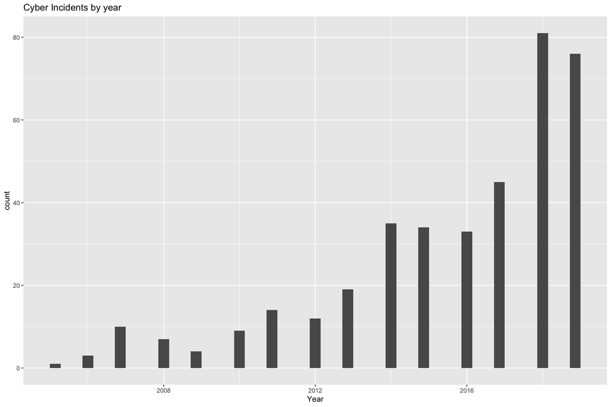

```r
cyber_2_1 %>%
  ggplot(aes(x=Year))+
  geom_histogram(bins = 50)+
  labs(title = "Cyber Incidents by year")
```

## 2. What is the most common types of cyber operation ? Trend by years?

### What types of incidents happen more often?

### Espionge

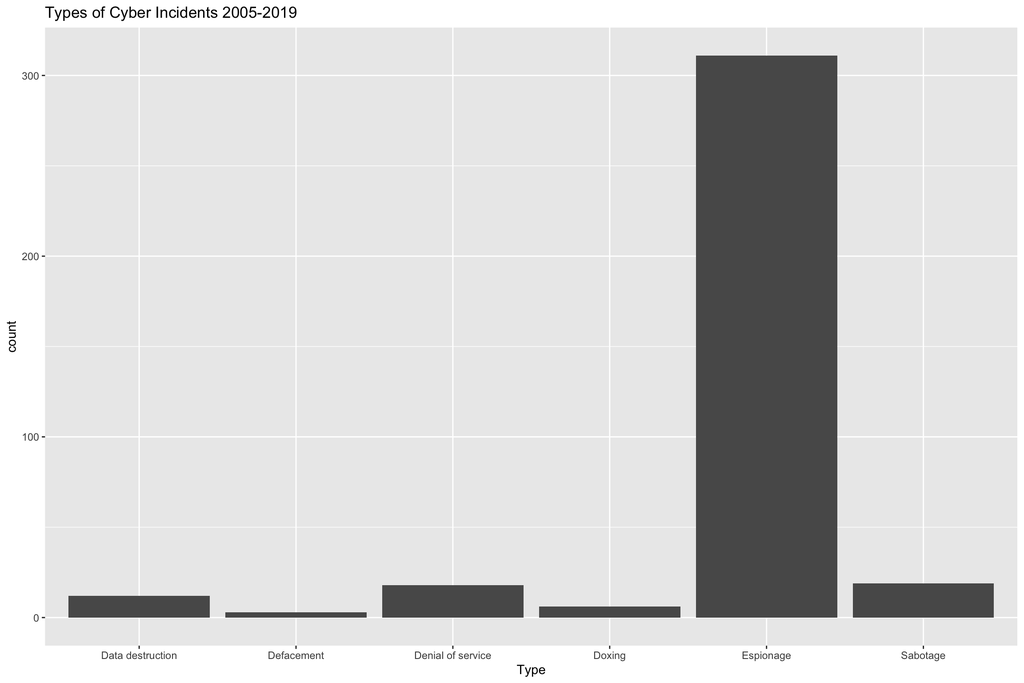

```r
df <- cyber_2_1 %>% filter (!is.na(Type))
df %>%
  ggplot(aes(x = Type))+
  geom_bar()+
  labs(title = "Types of Cyber Incidents 2005-2019")
```

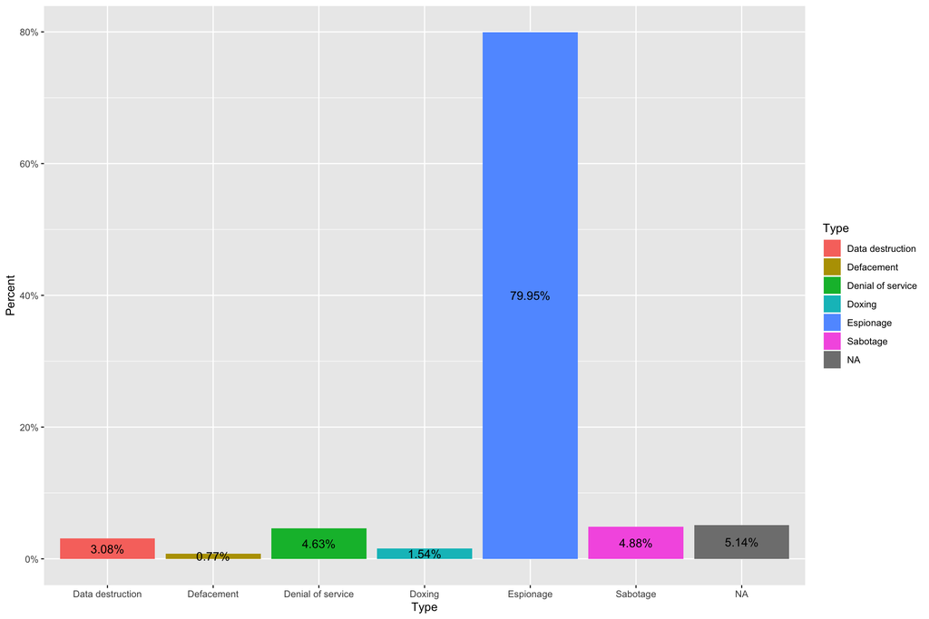

```r
# As precentage
cyber_2_1 %>% group_by(Type) %>%
  summarize(count = n()) %>%  # count records by species
  mutate(pct = count/sum(count)) %>%  # find percent of total
ggplot( aes(Type, pct, fill = Type)) +
  geom_bar(stat='identity') +
  geom_text(aes(label=scales::percent(pct)), position = position_stack(vjust = .5))+
  scale_y_continuous(labels = scales::percent)+labs(x = 'Type', y = 'Percent', fill = 'Type')
```

## Trend by years?

```r
# Cyber incidents by Types (use year group)

# summarize types by year groups
cyber_2_1$Year_group<-cut(cyber_2_1$Year,c(2004,2009,2012,2016,2019))
levels( cyber_2_1$Year_group) <- list( "2005-2008"="(2004,2009]", "2009-2011" ="(2009,2012]","2012-2015"="(2012,2016]","2016-2019" = "(2016,2019]")

suma_types = cyber_2_1 %>%
  filter(!is.na(Type)) %>%
  filter(!is.na(Year_group))%>%
  filter(!is.na(Sponsor)) %>%
  group_by(Type, Year_group, Sponsor) %>%
  summarize(sum = n()) %>%
  arrange(Year_group)

suma_types
```

```
## # A tibble: 80 x 4
## # Groups:   Type, Year_group [19]
##    Type              Year_group Sponsor                                   sum
##    <fct>             <fct>      <fct>                                   <int>
##  1 Denial of service 2005-2008  Israel                                      1
##  2 Denial of service 2005-2008  Korea (Democratic People's Republic of)     1
##  3 Denial of service 2005-2008  Russian Federation                          2
##  4 Denial of service 2005-2008  Taiwan, United States                       1
##  5 Espionage         2005-2008  China                                      19
##  6 Espionage         2005-2008  Russian Federation                          1
##  7 Data destruction  2009-2011  Iran (Islamic Republic of)                  1
##  8 Data destruction  2009-2011  United States, Israel                       1
##  9 Defacement        2009-2011  Iran (Islamic Republic of)                  1
## 10 Denial of service 2009-2011  Iran (Islamic Republic of)                  3
## # … with 70 more rows
```

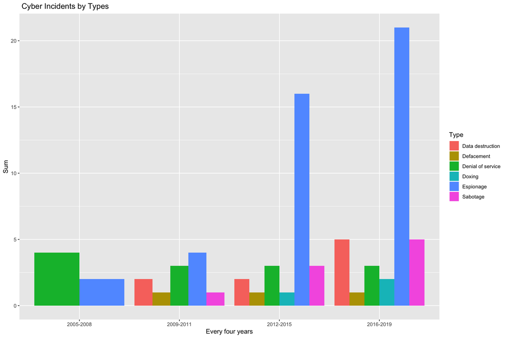

```r
ggplot(suma_types,  aes( x = Year_group, fill = Type)) +
  geom_bar(position = "dodge")+
  labs( y = "Sum", size = 8)+
  labs(x = "Every four years", size = 8)+
  labs(title = " Cyber Incidents by Types")
```

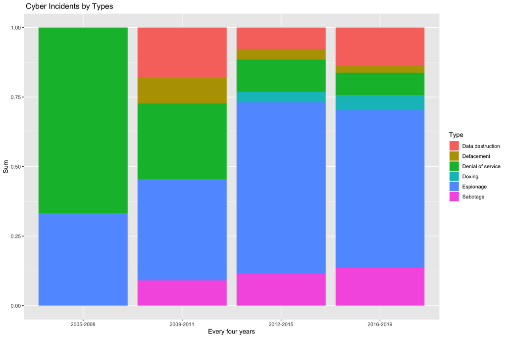

```r
# Another presence

ggplot(suma_types,aes( x = Year_group, fill = Type)) +
  geom_bar(position = "fill")+
  labs( y = "Sum", size = 8)+
  labs(x = "Every four years", size = 8)+
  labs(title = " Cyber Incidents by Types")
```

## 3. Countries are more likely to be Sponsors ### Sponsors

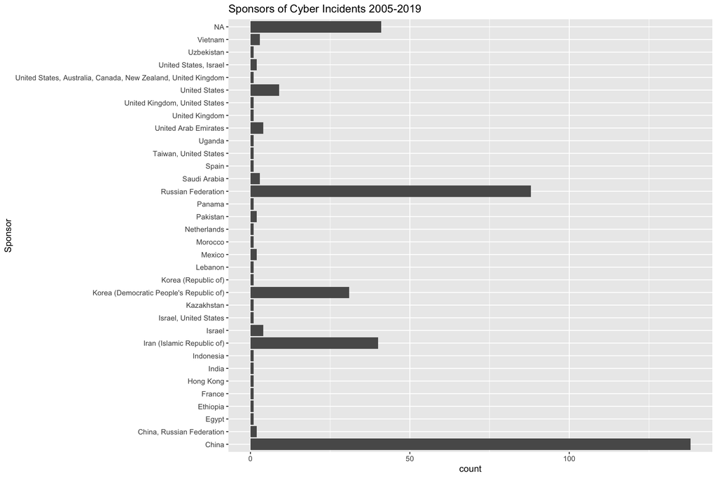

```r
cyber_2_1 %>%
  ggplot(aes(x = Sponsor))+
  geom_bar()+
  #scale_y_continuous(labels = scales::percent)+
  labs(title = "Sponsors of Cyber Incidents 2005-2019")+
  coord_flip()
```

## Top 10 sponsors?

```r
suma_sponstates_2 <-suma_sponstates %>% group_by(Sponsor) %>%
   summarize(count = n()) %>%  # count
  mutate(pct = count/sum(count)) %>%  # percentage
  arrange(desc(count/sum(count)))   # rank them


# What are top 10?
sponstates_top10 <- suma_sponstates_2[1:11,]
sponstates_top10
```

```
## # A tibble: 11 x 3
##    Sponsor                                 count    pct
##    <fct>                                   <int>  <dbl>
##  1 China                                      15 0.179
##  2 Iran (Islamic Republic of)                  9 0.107
##  3 Korea (Democratic People's Republic of)     9 0.107
##  4 Russian Federation                          9 0.107
##  5 Israel                                      4 0.0476
##  6 United States                               4 0.0476
##  7 United Arab Emirates                        3 0.0357
##  8 Vietnam                                     3 0.0357
##  9 China, Russian Federation                   2 0.0238
## 10 Mexico                                      2 0.0238
## 11 Saudi Arabia                                2 0.0238
```

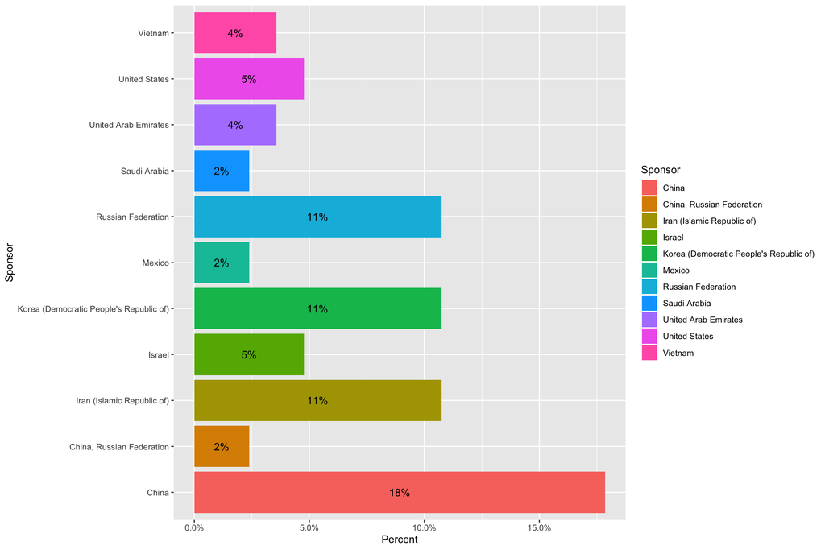

```r
# visualization
sponstates_top10 %>%
  ggplot(aes(Sponsor, pct, fill = Sponsor))+
  geom_bar(stat='identity') +
  geom_text(aes(label=scales::percent(pct)), position = position_stack(vjust = .5))+
  scale_y_continuous(labels = scales::percent)+labs(x = 'Sponsor', y = 'Percent', fill = 'Sponsor')+
  coord_flip()
```

4. Frequency of cyberattacks conducted by top five countries?

```r
cyber_2_1$Sponsor_maintype<-"other"

china_id<-which(cyber_2_1$Sponsor %in% "China" =="TRUE")
rf_id<-which(cyber_2_1$Sponsor %in% "Russian Federation" =="TRUE")
ir_id<-which(cyber_2_1$Sponsor %in% "Iran (Islamic Republic of)" =="TRUE")
ko_id<-which(cyber_2_1$Sponsor %in% "Korea (Democratic People's Republic of)" =="TRUE")


cyber_2_1$Sponsor_maintype[china_id]<-"China"
cyber_2_1$Sponsor_maintype[rf_id]<-"Russian Federation"
cyber_2_1$Sponsor_maintype[ir_id]<-"Iran"
cyber_2_1$Sponsor_maintype[ko_id]<-"Korea"

table(cyber_2_1$Sponsor_maintype)
```

```
##
##              China               Iran              Korea              other
##                138                 40                 31                 92
## Russian Federation
##                 88
```

```r
incident <- cyber_2_1$Sponsor_maintype
incident_date <- sort(cyber_2_1$Date,na.last = TRUE)

df <- data.frame(event = incident, event.date = incident_date) %>%
  arrange(event, event.date) %>%
  group_by(event) %>%
  mutate(previous = lag(event.date, 1)) %>%
  mutate(tae.1 = event.date - lag(event.date, 1)) #%>%
  # mutate(tae.2 = difftime(event.date , lag(event.date, 1))) %>%
  # mutate(tae.3 = as.duration(event.date %--% lag(event.date, 1))) %>%
  # mutate(tae.4 = tae.3 / ddays(1))
df
```

```
## # A tibble: 389 x 4
## # Groups:   event [5]
##    event event.date previous   tae.1
##    <fct> <date>     <date>     <drtn>
##  1 China 2006-12-04 NA          NA days
##  2 China 2007-05-16 2006-12-04 163 days
##  3 China 2007-09-09 2007-05-16 116 days
##  4 China 2007-09-24 2007-09-09  15 days
##  5 China 2007-10-04 2007-09-24  10 days
##  6 China 2008-03-21 2007-10-04 169 days
##  7 China 2008-05-05 2008-03-21  45 days
##  8 China 2008-08-13 2008-05-05 100 days
##  9 China 2009-03-20 2008-08-13 219 days
## 10 China 2010-01-25 2009-03-20 311 days
## # … with 379 more rows
```

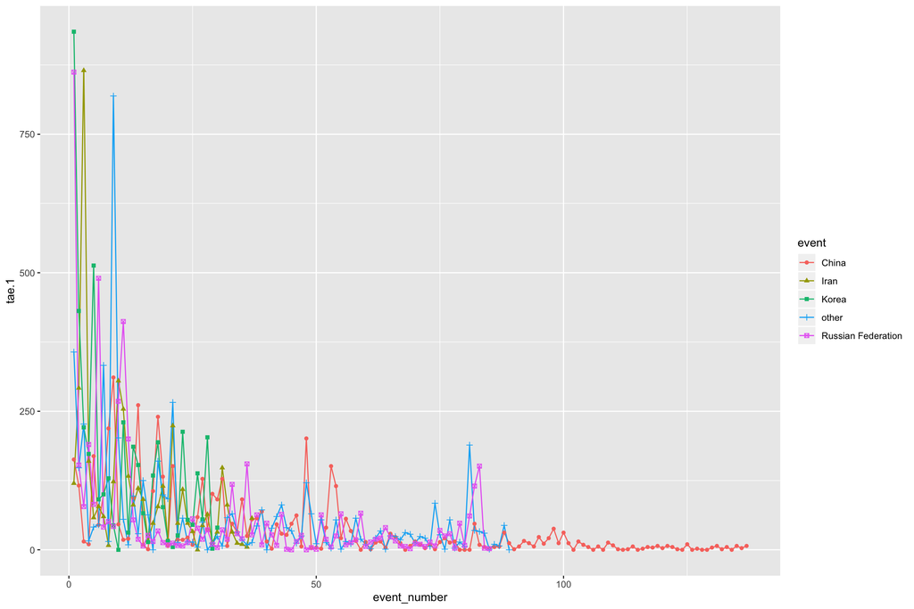

```r
# China               Iran              Korea              other Russian Federation

df$event_number<-c(NA,1:137,NA,1:39,NA,1:30,NA,1:91,NA,1:87)

ggplot(df, aes( x = event_number, y = tae.1, color = event ))+
  geom_line()+geom_point(aes(shape=event))
```

```r
  labs(title = "Diffs days per event trend")
```

```
## $title
## [1] "Diffs days per event trend"
##
## attr(,"class")
## [1] "labels"
```

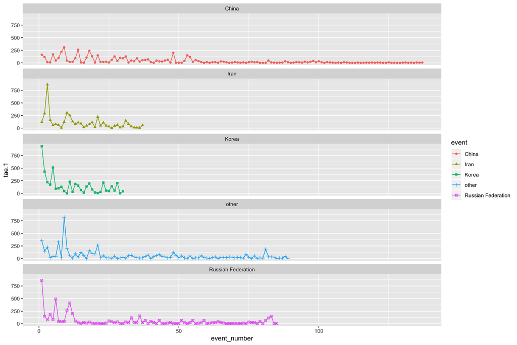

```r
  ggplot(df, aes( x = event_number, y = tae.1, color = event ))+
    geom_line()+geom_point(aes(shape=event))  + facet_wrap(~ event, nrow = 5)
```

```r
  labs(title = "Diffs days per event trend")
```

```
## $title
## [1] "Diffs days per event trend"
##
## attr(,"class")
## [1] "labels"
```

## 5. Do super power (US, China and Russia) more likely to sponsor cyber incidents, compared to middle power?

### Sponsor state + state power

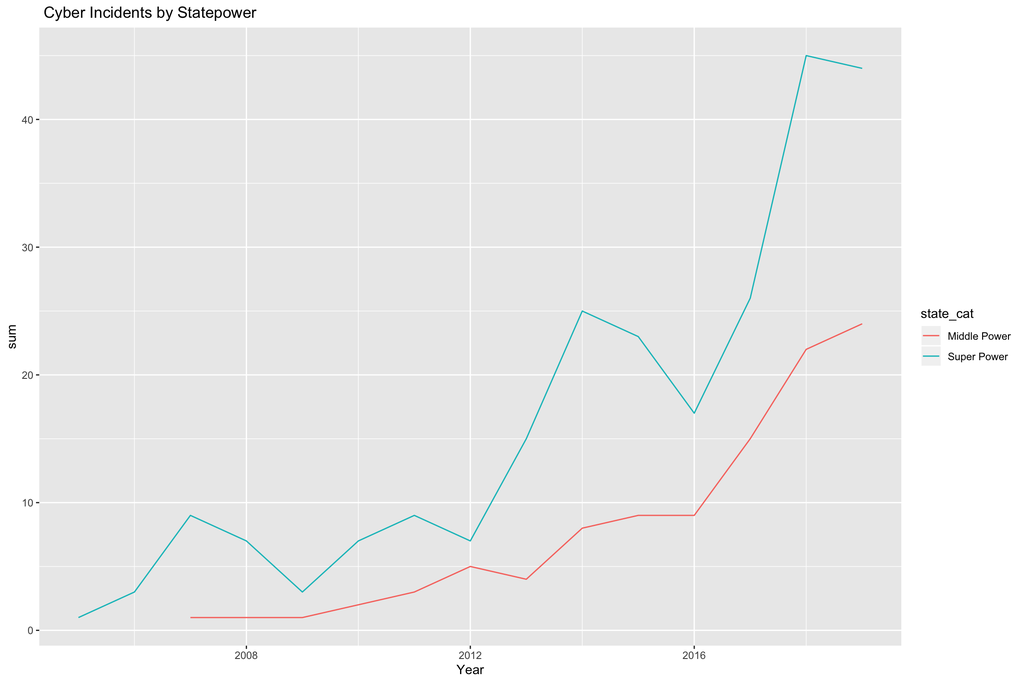

```r
suma_statepower %>%
  filter(state_cat!="NA") %>%
  ggplot(aes( x = Year, y = sum, color = state_cat))+
  geom_line()+
  labs(title = " Cyber Incidents by Statepower")
```

## 6. How does the state response to the cyber incident?

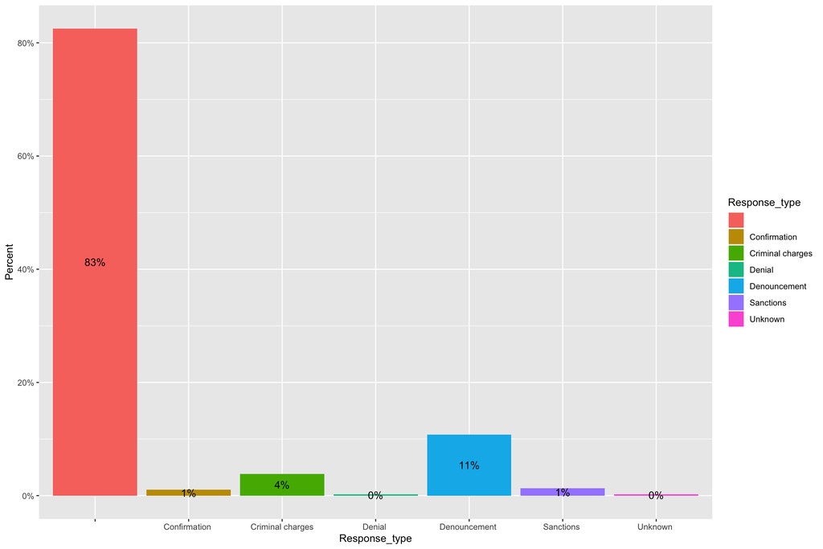

```r
cyber_2_1 %>% group_by(Response_type) %>%
  summarize(count = n()) %>%  # count records by response type
  mutate(pct = count/sum(count)) %>%  # find percent of total
ggplot( aes(Response_type, pct, fill = Response_type)) +
  geom_bar(stat='identity') +
  geom_text(aes(label=scales::percent(pct)), position = position_stack(vjust = .5))+
  scale_y_continuous(labels = scales::percent)+labs(x = 'Response_type', y = 'Percent', fill = 'Response_type')
```

# 5. Challenges: What was the most challenging aspect of the project? How did you solve this problem?

## Cleaning- How to seperate the “Response” column?

1. Random delimiter.
2. Can’t seperate simply by " "
3. Check and list all possible patterns.

## Analysis-Sequence Analysis (How to start out/ try and error)

1. Take advantage of online resourses. (Thanks Julia!) ps. coding is a long long way of learning and the online communities and blogs are really helpful! Steps:
- First, I observe the structure and realized why it did work at first
- After checking, I now know there are 68 rows containg information I want, but they may delimited by four or five spaces.
- So I broke them into five columns and made a list with same length
- Make a new dataframe and refinded it into a column containing words and the other cocntaining link.
2. Steps:
- want to know “How often does a cyber incident happen?”
- First, I should find out what are top 5 state sponsors since it’s not very informative to know some occational incidents and sponsors (and don’t want to make graph messy!)
- After identified top 5, I made another column “maintype”to classified “Sponsors” column.
- Then, I applied something found online to count the time gap.

# 6. Tools: What software tools did you use for this project? If you used anything that we didn’t cover in class, be sure to talk about it.

1. R
2. Excel

# 7. Next Steps: How would you take this project forward?

I am interested in the application of Deterrence theory in cyberspace. It is such a great thing that I incoperate what I learned this semester in this course and formal theory class, and hopefully I can make it more comprehensive and it could then becomes my thesis!!